# Wix_Mobilenet_Alpaca

## Functional API implementation of MobileNetV2 Transfer Learning to recognize Alpaca images

`Author`: Aditya Patel

Beauty of MobileNet is I can feed larger image than what mobilenet was originally trained on. By feeding 512 x 512 x 3 image, the number of paramters doesn't change. Just that convolutions reduces the heightand width of image, so a mobilenet fed with 512 x 512 x 3 images o outputs 16x16x1280 array. i.e. 1280 edges detected of size 16 x 16 pixels. Instead if I feed say 200 x 200 image to it, the only thing that will happen is output of mobilenet will be 8x8x1280 i.e. 1280 edges will be detected by convfilters but the images of those edges will be small i.e. 8x8 instead of 16x16. The total number of edges will remain 1280 in both cases. Even if i feed it 2048 x 2048 x 3 images, mobilenet will output 1280 edges (also called featuremaps) of shape 64x64 pixels each. That's the only difference. Eventually, if i'm gonna do a globalpool over volume, 8x8, 16x16,64x64 all will be reduced to 1 single number or i can do flatten and feed it forward.

```python
import matplotlib.pyplot as plt
import numpy as np
import os,pydot
import tensorflow as tf
import tensorflow.keras.layers as tfl
from tensorflow import keras
from tensorflow.keras.preprocessing import image_dataset_from_directory
from tensorflow.keras.layers.experimental.preprocessing import RandomFlip, RandomRotation
from keras.preprocessing.image import load_img
from keras_visualizer import visualizer
```

```
(1024, 680)
```

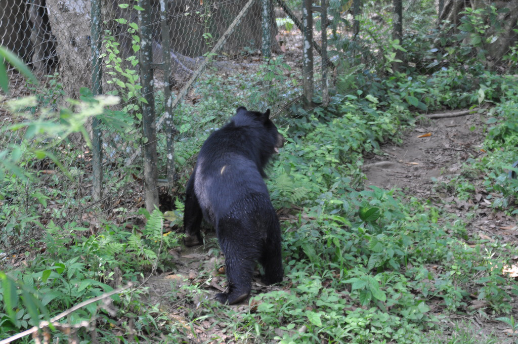

```python
sample_image = load_img('dataset/not alpaca/0a85e62973f2bcf6.jpg')
print(sample_image.size)
# this image is 1024 x 680 x 3. I noticed all images have different widths
# slightly. I'll use 512 x 512
sample_image
```

```python
#   -----------------------------------------------------------------------------------
#   For binary classification, Class 0 --> 'not alpaca', class 1 --> 'alpaca'
#   This is bcos I imported class_names as a list whose 0th element is 'not alpaca'
#   and whose 1st element is 'alpaca'. Alternatively, if I had imported class_names = ['alpaca', 'not alpaca'],
#   then Class 0 ---> 'alpaca' and Class 1 ---> 'not alpaca'. Both are correct ways to import but
#   but when mymodel's final sigmoid layer outputs say 0.8, I need to know what is
#   name of layer 0 class and what is the name if layer 1 class

#   Also, seed and class_names, validation_split, image size should be identical for both
#   ---------------------------------------------------------------------------------
```

```python
# Below I chose 512 x 512 to keep image large. I think shrinking image is big mistake if we have horsepower to
# feed it in model. This could instead be 200 x 200, 100 x 100, 256 x 256, 1024 x 1024 anything is fine
# But they all must be same size

directory = "dataset/"
train_dataset = image_dataset_from_directory(directory,
                                             shuffle=True,
                                             class_names=['not alpaca', 'alpaca'],
                                             image_size = (512,512),
                                             validation_split=0.2,
                                             subset='training',
                                             seed=42)
validation_dataset = image_dataset_from_directory(directory,
                                             shuffle=True,
                                             validation_split=0.2,
                                             subset='validation',
                                             seed=42,
                                             class_names=['not alpaca', 'alpaca'],
                                             image_size = (512,512))
for images, labels in train_dataset:
    print('image shape is {}, label shape is {}'.format(images.shape, labels.shape))

class_names = train_dataset.class_names
print(class_names)
```

```
Found 327 files belonging to 2 classes.
Using 262 files for training.
Found 327 files belonging to 2 classes.
Using 65 files for validation.
image shape is (32, 512, 512, 3), label shape is (32,)
image shape is (32, 512, 512, 3), label shape is (32,)
image shape is (32, 512, 512, 3), label shape is (32,)
image shape is (32, 512, 512, 3), label shape is (32,)
image shape is (32, 512, 512, 3), label shape is (32,)
image shape is (32, 512, 512, 3), label shape is (32,)
image shape is (32, 512, 512, 3), label shape is (32,)
image shape is (32, 512, 512, 3), label shape is (32,)
image shape is (6, 512, 512, 3), label shape is (6,)
['not alpaca', 'alpaca']
```

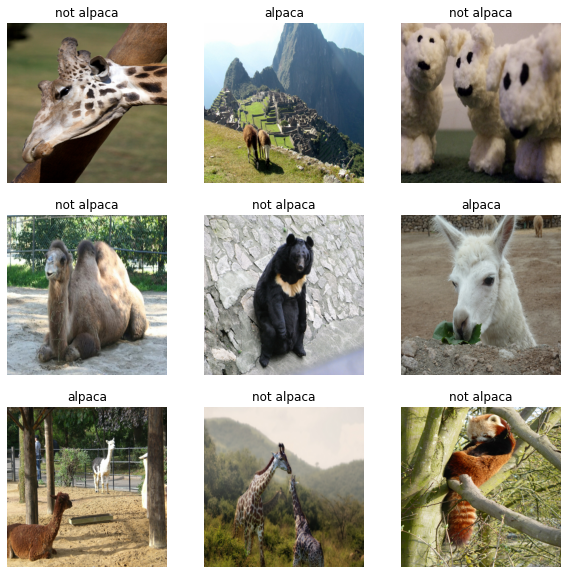

```python
plt.figure(figsize=(10, 10))
for images, labels in train_dataset.take(1):
    for i in range(9):
        ax = plt.subplot(3, 3, i + 1)
        plt.imshow(images[i].numpy().astype("uint8"))
        plt.title(class_names[labels[i]])
        plt.axis("off")
```